Universidad Nacional Autónoma de México - Licenciatura en ciencias genómicas

Introducción a Ciencia de Datos 2021 - Tarea 3

**Salvador González Juárez**

Resolver los siguientes ejercicios.

## 1. Abre el archivo hersdata.csv usado en la clase de la primera sesión.

```r
# Leer el archivo e imprimir algunos registros
setwd("/home/salvador/Documentos/Licenciatura_Ciencias_Genomicas/Cuarto_Semestre/Ciencia_Datos/Tarea_3")
hersdata <- read.table("../Clase_1/hersdata.csv",sep = ",",header = T)
head(hersdata,n = 5)
```

```
##                HT age           raceth nonwhite smoking drinkany exercise
## 1         placebo  70 African American      yes      no       no       no
## 2         placebo  62 African American      yes      no       no       no
## 3 hormone therapy  69            White       no      no       no       no
## 4         placebo  64            White       no     yes      yes       no
## 5         placebo  65            White       no      no       no       no
##                physact medcond htnmeds statins diabetes dmpills insulin weight
## 1     much more active       0     yes     yes       no      no      no   73.8
## 2     much less active       1     yes      no       no      no      no   70.9
## 3      about as active       0     yes      no      yes      no      no  102.0
## 4     much less active       1     yes      no       no      no      no   64.4
## 5 somewhat less active       0      no      no       no      no      no   57.9
##     BMI waist   WHR glucose tchol   LDL HDL  TG SBP DBP age10
## 1 23.69  96.0 0.932      84   189 122.4  52  73 138  78   7.0
## 2 28.62  93.0 0.964     111   307 241.6  44 107 118  70   6.2
## 3 42.51 110.2 0.782     114   254 166.2  57 154 134  78   6.9
## 4 24.39  87.0 0.877      94   204 116.2  56 159 152  72   6.4
## 5 21.90  77.0 0.794     101   214 150.6  42 107 175  95   6.5
```

## 2. Elimina todos los NAs del archivo. ¿Cuántas observaciones se eliminaron de los datos?

```r
# Filtrar los registros y calcular cuantos fueron omitidos
hersdata_filtered <- na.omit(hersdata)
nrow(hersdata) - nrow(hersdata_filtered)
```

```
## [1] 20
```

**Se eliminaron 20 observaciones de los datos por poseer valores nulos.**

## 3. Crea un intervalo de las edades de 5 en 5 y realiza una gráfica de barras de la frecuencia de cada uno. ¿Cómo es la distribución de estos grupos de edades?

```r
# Analizar el resumen de los valores de la edad en los registros filtrados
hersdata <- hersdata_filtered
summary(hersdata$age)
```

```
##    Min. 1st Qu.  Median    Mean 3rd Qu.    Max.
##   44.00   62.00   67.00   66.65   72.00   79.00
```

```r
# Importar la libreria requerida para realizar la codificacion de datos
library(qdap)
# Construir los intervalos de la categoria edad
hersdata$age_group <- findInterval(hersdata$age, c(40, 45, 50, 55, 60, 65, 70, 75, 80))
hersdata$age_group[1:7]
```

```
## [1] 7 5 6 5 6 6 7
```

```r
# Remplazar los valores por el nombre de los intervalos
hersdata$age_group <- multigsub(sort(unique(hersdata$age_group)),
                                c("40-45", "45-50", "50-55", "55-60", "60-65", "65-70", "70-75", "75-80"), hersdata$age_group)
hersdata$age_group[1:7]
```

```
## [1] "70-760-65" "60-65"     "660-65-70" "60-65"     "660-65-70" "660-65-70"
## [7] "70-760-65"
```

```r
# Por alguna extraña razon, debo volver a correr el codigo para que funcione
hersdata$age_group <- multigsub(sort(unique(hersdata$age_group)),
                                c("40-45", "45-50", "50-55", "55-60", "60-65", "65-70", "70-75", "75-80"), hersdata$age_group)
hersdata$age_group[1:7]
```

```
## [1] "70-75" "60-65" "65-70" "60-65" "65-70" "65-70" "70-75"
```

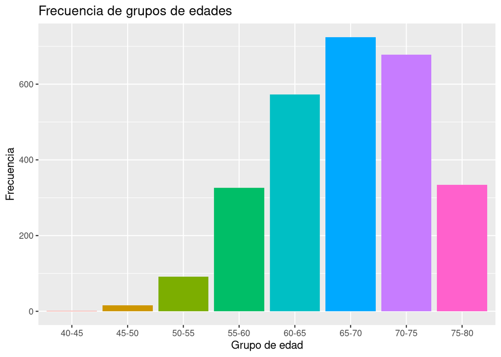

```r
# Importar la libreria requerida para graficar
library(ggplot2)
# Obtener la frecuencia con table
age_group <- as.data.frame(table(hersdata$age_group))

# Graficar la distribucion de los intervalos por edad
ggplot(age_group, aes(x = Var1, y = Freq, fill = Var1)) +
  geom_bar(stat = "identity") +
  theme(legend.position = "none") +
  labs(title = "Frecuencia de grupos de edades", x = "Grupo de edad", y = "Frecuencia")
```

## 4. Crea un intervalo para el valor de BMI para obtener una variable discreta que indique los subgrupos encontrados en la siguiente página: http://www.clinicavespucio.cl/calculo-del-imc/ (con subgrupos me refiero a los que se encuentran en blanco en la tabla). Realiza una gráfica de barras donde indiques la frecuencia de cada grupo. ¿Cuáles son los grupos más frecuentes? ¿Cuáles los menos?

```r
# Analizar el resumen de los valores de BMI en los registros filtrados
hersdata <- hersdata_filtered
summary(hersdata$BMI)
```

```
##    Min. 1st Qu.  Median    Mean 3rd Qu.    Max.
##   15.21   24.62   27.74   28.56   31.71   54.13
```

```r
# Construir los intervalos de la categoria BMI
hersdata$BMI_group <- findInterval(hersdata$BMI, c(15, 16, 17, 18.5, 25, 30, 35, 40, 55))
hersdata$BMI_group[1:7]
```

```
## [1] 4 5 8 4 4 5 6
```

```r
# Remplazar los valores por el nombre de los intervalos
hersdata$BMI_group <- multigsub(sort(unique(hersdata$BMI_group)),
                                c("Delgadez severa", "Delgadez moderada", "Delgadez aceptable", "Normal", "Pre-obeso", "Obeso tipo I",
                                  "Obeso tipo II", "Obeso tipo III"), hersdata$BMI_group)
hersdata$BMI_group[1:7]
```

```
## [1] "Normal"         "Pre-obeso"      "Obeso tipo III" "Normal"
## [5] "Normal"         "Pre-obeso"      "Obeso tipo I"
```

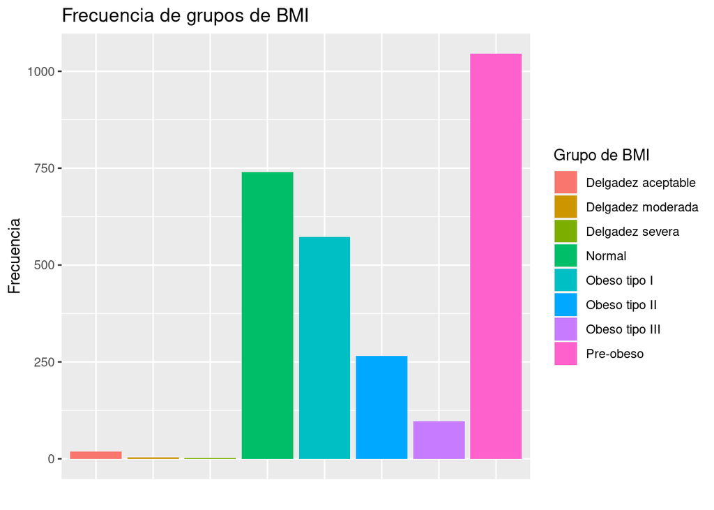

```r
# Obtener la frecuencia con table
BMI_group <- as.data.frame(table(hersdata$BMI_group))

# Graficar la distribucion de los intervalos por BMI
ggplot(BMI_group, aes(x = Var1, y = Freq, fill = Var1)) +
  geom_bar(stat = "identity") +
  theme(axis.ticks.x = element_blank(), axis.text.x=element_blank()) +
  scale_fill_discrete(name = "Grupo de BMI") +
  labs(title = "Frecuencia de grupos de BMI", x = "", y = "Frecuencia")
```

**Los grupos mas frecuentes son los de Pre-obeso, Normal y Obeso tipo I. Los grupo menos frecuentes son los tres tipos de delgadez.**

## 5. Codifica todas las variables binarias que tienen “yes” y “no” a 0 y 1 con multigsub(). Crea una función que automáticamente reemplace estos valores de las columnas que selecciones para que no tengas que correr la misma línea muchas veces.

```r
# Mostrar algunos de los registros para ver su contenido
head(hersdata)
```

```
##                HT age           raceth nonwhite smoking drinkany exercise
## 1         placebo  70 African American      yes      no       no       no
## 2         placebo  62 African American      yes      no       no       no
## 3 hormone therapy  69            White       no      no       no       no
## 4         placebo  64            White       no     yes      yes       no
## 5         placebo  65            White       no      no       no       no
## 6 hormone therapy  68 African American      yes      no      yes       no
##                physact medcond htnmeds statins diabetes dmpills insulin weight
## 1     much more active       0     yes     yes       no      no      no   73.8
## 2     much less active       1     yes      no       no      no      no   70.9
## 3      about as active       0     yes      no      yes      no      no  102.0
## 4     much less active       1     yes      no       no      no      no   64.4
## 5 somewhat less active       0      no      no       no      no      no   57.9
## 6      about as active       0      no      no       no      no      no   60.9
##     BMI waist   WHR glucose tchol   LDL HDL  TG SBP DBP age10      BMI_group
## 1 23.69  96.0 0.932      84   189 122.4  52  73 138  78   7.0         Normal
## 2 28.62  93.0 0.964     111   307 241.6  44 107 118  70   6.2      Pre-obeso
## 3 42.51 110.2 0.782     114   254 166.2  57 154 134  78   6.9 Obeso tipo III
## 4 24.39  87.0 0.877      94   204 116.2  56 159 152  72   6.4         Normal
## 5 21.90  77.0 0.794     101   214 150.6  42 107 175  95   6.5         Normal
## 6 29.05  96.0 1.000     116   212 137.8  52 111 174  98   6.8      Pre-obeso
```

```r
# Analizar si las categorias seleccionadas contienen solamente "yes" o "no"
apply(hersdata[, c(4, 5, 6, 7, 10, 11, 12, 13, 14)], 2, table)
```

```
## $nonwhite
##
##   no  yes
## 2433  310
##
## $smoking
##
##   no  yes
## 2389  354
##
## $drinkany
##
##        no  yes
##    2 1669 1072
##
## $exercise
##
##   no  yes
## 1682 1061
##
## $htnmeds
##
##   no  yes
##  490 2253
##
## $statins
##
##   no  yes
## 1748  995
##
## $diabetes
##
##   no  yes
## 2021  722
##
## $dmpills
##
##   no  yes
## 2479  264
##
## $insulin
##
##   no  yes
## 2473  270
```

```r
# Omito los registros que poseen valores en blanco en lugar de "yes" o "no"
hersdata <- hersdata[!(hersdata$drinkany == ""),]
```

```r
# Esta funcion cambia una pareja de valores de tipo caracter por valores numericos (0 y 1)
# en las columnas indicadas de un dataframe
coding <- function(dataset, categories){
  for (i in categories) {
    dataset[,i] <- as.factor(multigsub(sort(unique(dataset[,i])), c(0, 1), dataset[,i]))
  }
  return(dataset)
}
```

```r
# Cambiar todos los "yes" y "no" por 0 y 1 en el dataframe
new_hersdata <- coding(dataset=hersdata, categories=c(4, 5, 6, 7, 10, 11, 12, 13, 14))
head(new_hersdata)
```

```
##                HT age           raceth nonwhite smoking drinkany exercise
## 1         placebo  70 African American        1       0        0        0
## 2         placebo  62 African American        1       0        0        0
## 3 hormone therapy  69            White        0       0        0        0
## 4         placebo  64            White        0       1        1        0
## 5         placebo  65            White        0       0        0        0
## 6 hormone therapy  68 African American        1       0        1        0
##                physact medcond htnmeds statins diabetes dmpills insulin weight
## 1     much more active       0       1       1        0       0       0   73.8
## 2     much less active       1       1       0        0       0       0   70.9
## 3      about as active       0       1       0        1       0       0  102.0
## 4     much less active       1       1       0        0       0       0   64.4
## 5 somewhat less active       0       0       0        0       0       0   57.9
## 6      about as active       0       0       0        0       0       0   60.9
##     BMI waist   WHR glucose tchol   LDL HDL  TG SBP DBP age10      BMI_group
## 1 23.69  96.0 0.932      84   189 122.4  52  73 138  78   7.0         Normal
## 2 28.62  93.0 0.964     111   307 241.6  44 107 118  70   6.2      Pre-obeso
## 3 42.51 110.2 0.782     114   254 166.2  57 154 134  78   6.9 Obeso tipo III
## 4 24.39  87.0 0.877      94   204 116.2  56 159 152  72   6.4         Normal
## 5 21.90  77.0 0.794     101   214 150.6  42 107 175  95   6.5         Normal
## 6 29.05  96.0 1.000     116   212 137.8  52 111 174  98   6.8      Pre-obeso
```

## 6. Crea una distribución normal de la misma longitud de los datos, con la media y la desviación estándar de la columna glucosa. Combina estos datos normales y los datos de la columna glucosa en un dataframe.

```r
# Simular una distribucion normal de los datos
set.seed(4)
datos_norm <- rnorm(nrow(hersdata), mean=mean(hersdata$glucose), sd=sd(hersdata$glucose))
datos <- data.frame(datos_norm, hersdata$glucose)
colnames(datos) <- c("Normales","Reales")
head(datos)
```

```
##    Normales Reales
## 1 120.06446     84
## 2  92.12559    111
## 3 144.88072    114
## 4 134.01924     94
## 5 172.27593    101
## 6 137.45232    116
```

## 7. Realiza un histograma para estos dos datos, una gráfica cuantil-cuantil, una gráfica Cullen-Frey y obtén su asimetría. ¿Qué observas?

### Histograma

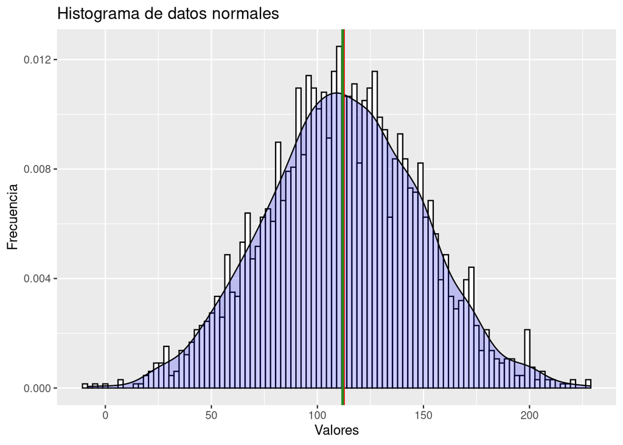

```r
# Graficar el histograma de los datos normales
ggplot(datos, aes(Normales)) +
  geom_histogram(aes(y = ..density..), bins = 100, color = "black", fill = "white") +
  geom_density(alpha = 0.2, fill = "blue") +
  geom_vline(xintercept = mean(datos$Normales), color = "red", size = 1) +
  geom_vline(xintercept = median(datos$Normales), color = "forestgreen", size = 1) +
  labs(title = "Histograma de datos normales", x = "Valores", y = "Frecuencia")
```

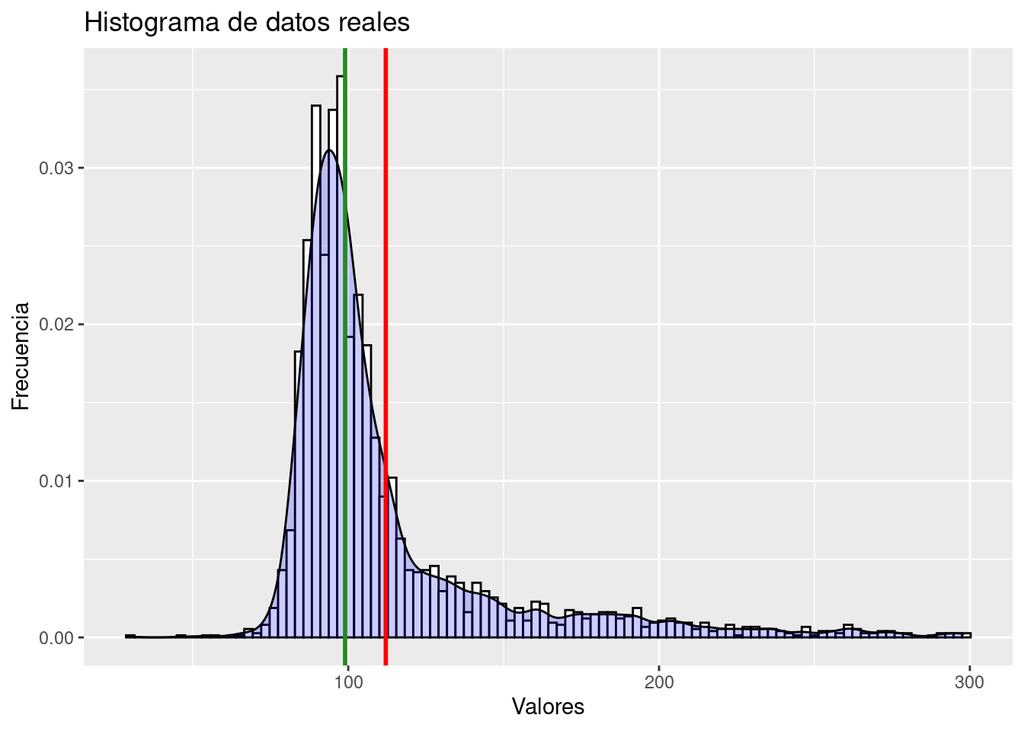

```r
# Graficar el histograma de los datos reales
ggplot(datos, aes(Reales)) +
  geom_histogram(aes(y = ..density..), bins = 100, color = "black", fill = "white") +
  geom_density(alpha = 0.2, fill = "blue") +
  geom_vline(xintercept = mean(datos$Reales), color = "red", size = 1) +
  geom_vline(xintercept = median(datos$Reales), color = "forestgreen", size = 1) +
  labs(title = "Histograma de datos reales", x = "Valores", y = "Frecuencia")
```

### Gráfica cuantil-cuantil

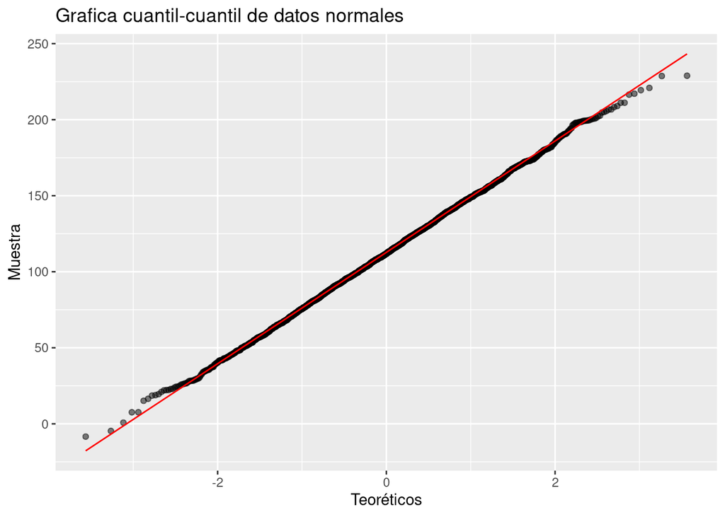

```r
# Graficar cuantil-cuantil de los datos normales
ggplot(datos, aes(sample = Normales)) +
  stat_qq(alpha = 0.5) +
  stat_qq_line(color = "red") +
  labs(title = "Grafica cuantil-cuantil de datos normales", x = "Teoréticos", y = "Muestra")
```

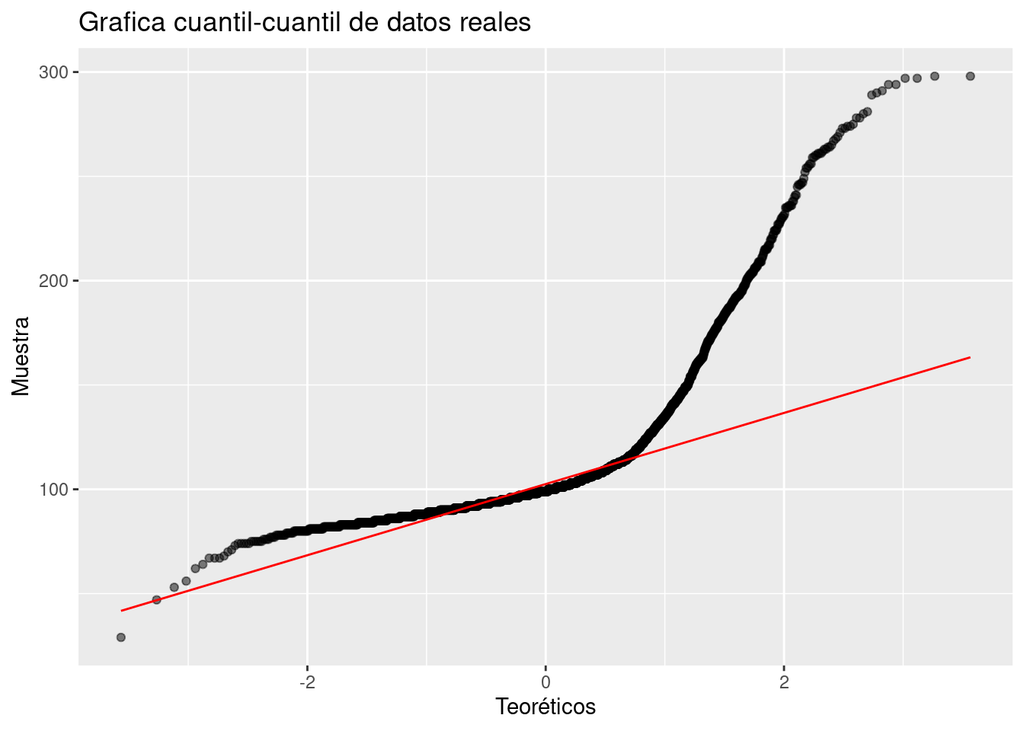

```r
# Graficar cuantil-cuantil de los datos reales
ggplot(datos, aes(sample = Reales)) +
  stat_qq(alpha = 0.5) +
  stat_qq_line(color = "red") +
  labs(title = "Grafica cuantil-cuantil de datos reales", x = "Teoréticos", y = "Muestra")
```

### Gráfica Cullen-Frey

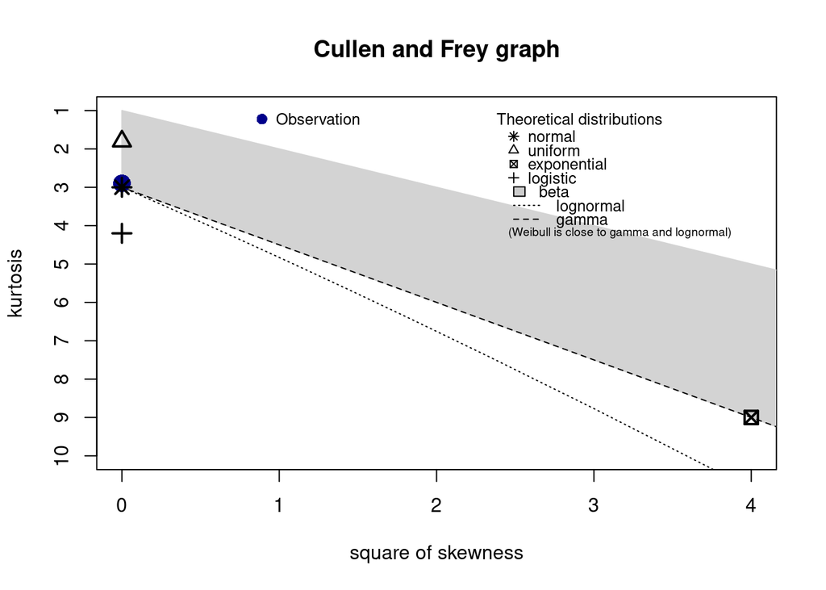

```
## summary statistics
## ------
## min:  -8.39954   max:  228.8923
## median:  111.8803
## mean:  112.2787
## estimated sd:  36.35552
## estimated skewness:  0.00707222
## estimated kurtosis:  2.898117
```

```r
# Importar la libreria requerida para graficar Cullen-Frey
library("fitdistrplus")
# Graficar Cullen-Frey para los datos normales y los reales
descdist(datos$Normales)
```

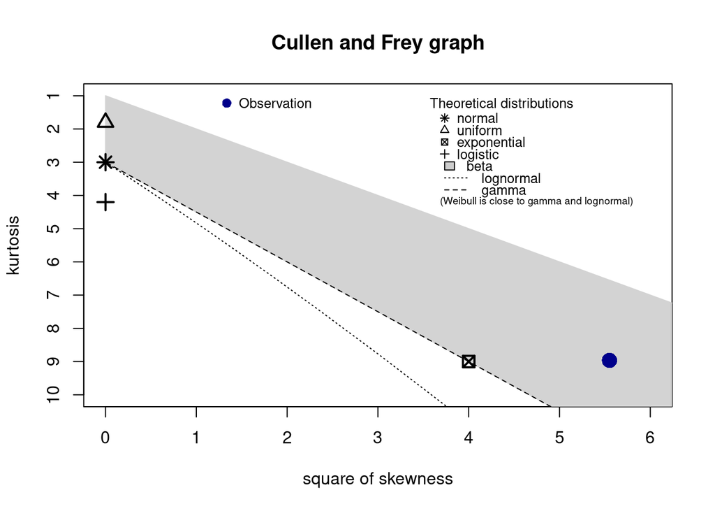

```
## summary statistics
## ------
## min:  29   max:  298
## median:  99
## mean:  112.0883
## estimated sd:  36.7981
## estimated skewness:  2.355959
## estimated kurtosis:  8.964797
```

```r
descdist(datos$Reales)
```

### Asimetría

```r
# Importar la libreria requerida para calcular la asimetria
library("e1071")
```

```r
# Calcular la asimetria de los datos normales y los reales
skewness(datos$Normales)
```

```
## [1] 0.007064481
```

```r
skewness(datos$Reales)
```

```
## [1] 2.353381
```

## 8. Utiliza la función bestNormalize() para encontrar la mejor forma de normalizar los datos. Utiliza esta función para normalizarlos y realiza los mismos pasos del punto 7. ¿Cómo cambiaron los datos?

```r
# Importar la libreria para hallar el mejor metodo de normalizacion
library("bestNormalize")
# Buscar el mejor metodo de normalizacion
set.seed(8)
bestNormalize(datos$Reales)
```

```
## Best Normalizing transformation with 2741 Observations
##  Estimated Normality Statistics (Pearson P / df, lower => more normal):
##  - arcsinh(x): 10.2968
##  - Box-Cox: 6.0361
##  - Center+scale: 19.1632
##  - Exp(x): 299.402
##  - Log_b(x+a): 10.2968
##  - orderNorm (ORQ): 1.674
##  - sqrt(x + a): 14.0217
##  - Yeo-Johnson: 6.1434
## Estimation method: Out-of-sample via CV with 10 folds and 5 repeats
##
## Based off these, bestNormalize chose:
## orderNorm Transformation with 2741 nonmissing obs and ties
##  - 201 unique values
##  - Original quantiles:
##   0%  25%  50%  75% 100%
##   29   91   99  114  298
```

```r
# Aplicar la funcion de normalizacion indicada y guardar los datos en el dataframe
norm_datos <- orderNorm(datos$Reales)
datos$Normalizados <- norm_datos$x.t
```

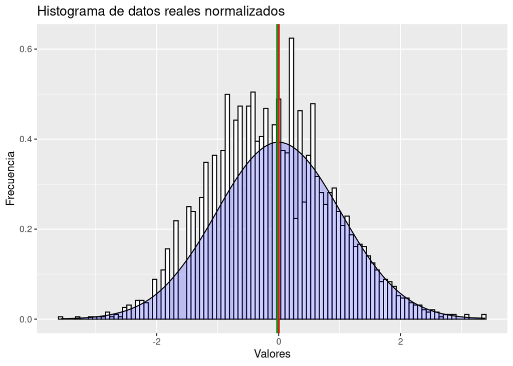

```r
# Graficar el histograma de los datos reales normalizados
ggplot(datos, aes(Normalizados)) +
  geom_histogram(aes(y = ..density..), bins = 100, color = "black", fill = "white") +
  geom_density(alpha = 0.2, fill = "blue") +
  geom_vline(xintercept = mean(datos$Normalizados), color = "red", size = 1) +
  geom_vline(xintercept = median(datos$Normalizados), color = "forestgreen", size = 1) +
  labs(title = "Histograma de datos reales normalizados", x = "Valores", y = "Frecuencia")
```

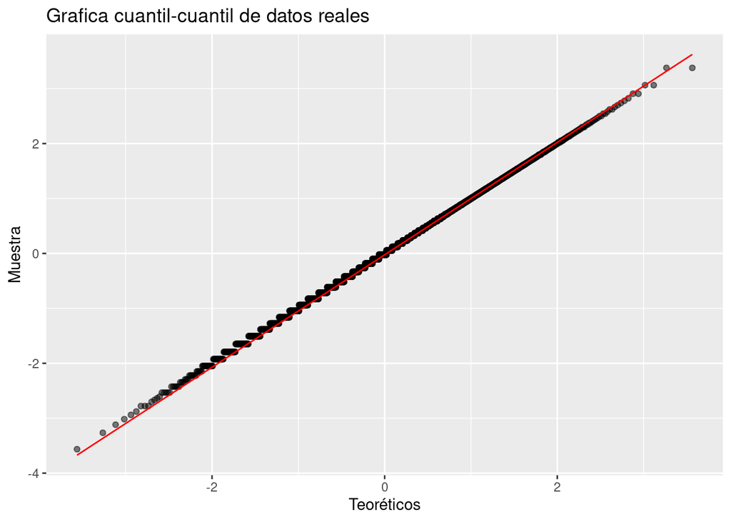

```r
# Graficar cuantil-cuantil de los datos reales normalizados
ggplot(datos, aes(sample = Normalizados)) +
  stat_qq(alpha = 0.5) +
  stat_qq_line(color = "red") +
  labs(title = "Grafica cuantil-cuantil de datos reales", x = "Teoréticos", y = "Muestra")
```

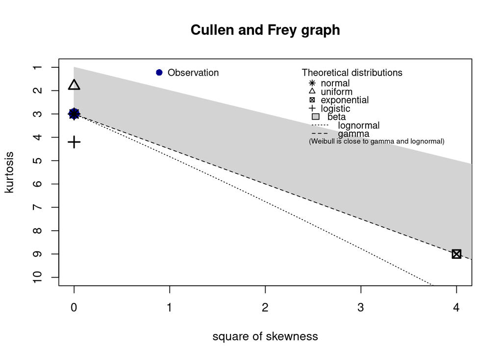

```
## summary statistics
## ------
## min:  -3.564299   max:  3.378185
## median:  -0.02240698
## mean:  0.0001675136
## estimated sd:  0.9993057
## estimated skewness:  0.0006561965
## estimated kurtosis:  2.985769
```

```r
# Graficar Cullen-Frey para los datos reales normalizados
descdist(datos$Normalizados)
```

```r
# Calcular la asimetria de los datos reales normalizados
skewness(datos$Normalizados)
```

```
## [1] 0.0006554784
```

## 9. Descarga los datos encontrados en la siguiente liga: http://archive.ics.uci.edu/ml/machine-learning-databases/00401/. El archivo llamado “data.csv” contiene datos de expresión para 20531 genes y 801 muestras de 5 diferentes tipos de cáncer obtenidos de la base de datos de The Cancer Genome Atlas (TCGA). El archivo llamado “labels.csv” contiene el nombre del tipo de cáncer al que pertenece cada una de las 801 muestras (en la página de TCGA puedes encontrar el nombre completo del tipo de cáncer por abreviatura: https://gdc.cancer.gov/resources-tcga-users/tcga-code-tables/tcga-study-abbreviations). En la página de cursos encontrarás un archivo llamado “TCGA_genes.txt”, el cual contiene el nombre e identificador de los 20531 genes (algunos no tienen nombre, pero puedes consultar qué región genómica es con el identificador en NCBI gene: https://www.ncbi.nlm.nih.gov/gene/).

```r
# Abir y analizar el archivo que contiene los niveles de expresion
data_cancer <- read.table("data.csv",sep = ",",header = T)
#data_cancer[1:7, 1:7]
#dim(data_cancer)

# Abrir y usar el archivo que contiene los nombres de cada tejido para agregarlos al dataframe
labels_cancer <- read.table("labels.csv",sep = ",", header = T)
#labels_cancer[1:7,]
#dim(labels_cancer)
data_cancer$X <- labels_cancer$Class

# Abir y analizar el archivo que contiene los nombres de cada gen
genes_cancer <- read.table("TCGA_genes.txt",sep = " ",header = T)
#genes_cancer[1:40,]
#dim(genes_cancer)

# Importar una libreria para buscar informacion genomica
library(rentrez)

# Buscar los nombres faltantes de la lista de genes
summary_genes <- entrez_summary(db="gene", id=genes_cancer$id[1:29])
genes_cancer$name[1:29] <- as.vector(extract_from_esummary(summary_genes, "name"))

# Agregar el nombre de cada gen en el dataframe
colnames(data_cancer) <- c("X", genes_cancer$name)
data_cancer[1:7, 1:7]
```

```
##      X LOC100130426  UBE2Q2P3 UBE2Q2P2  HMGB1P1    TIMM23 MOXD2
## 1 PRAD            0 2.0172093 3.265527 5.478487 10.431999     0
## 2 LUAD            0 0.5927321 1.588421 7.586157  9.623011     0
## 3 PRAD            0 3.5117590 4.327199 6.881787  9.870730     0
## 4 PRAD            0 3.6636179 4.507649 6.659068 10.196184     0
## 5 BRCA            0 2.6557411 2.821547 6.539454  9.738265     0
## 6 PRAD            0 3.4678533 3.581918 6.620243  9.706829     0
## 7 KIRC            0 1.2249664 1.691177 6.572007  9.640511     0
```

## 10. Realiza un PCA con los datos dados. Grafícalo y agrupa las observaciones por tipo de cáncer. Coloca elipses a la gráfica.

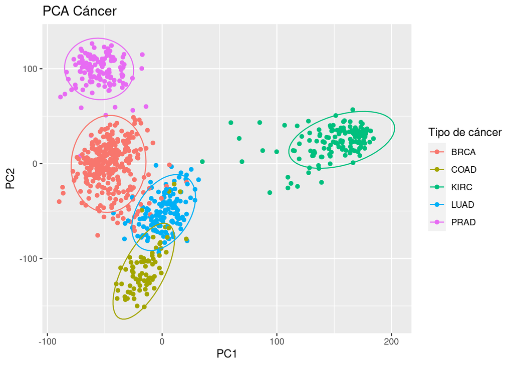

```r
# Realizar el PCA de forma automatica
PCA <- prcomp(data_cancer[,2:ncol(data_cancer)])

# Graficar el PCA con elipses
PrinComps <- as.data.frame(PCA$x)
PrinComps$CancerType <- data_cancer[,1]
ggplot(PrinComps, aes(x = PC1, y = PC2, color = CancerType)) +
  geom_point() +
  stat_ellipse() +
  labs(title = "PCA Cáncer", x = "PC1", y = "PC2", color = "Tipo de cáncer")
```

## 11. Obtén la proporción de la varianza explicada por cada componente principal y grafícala.

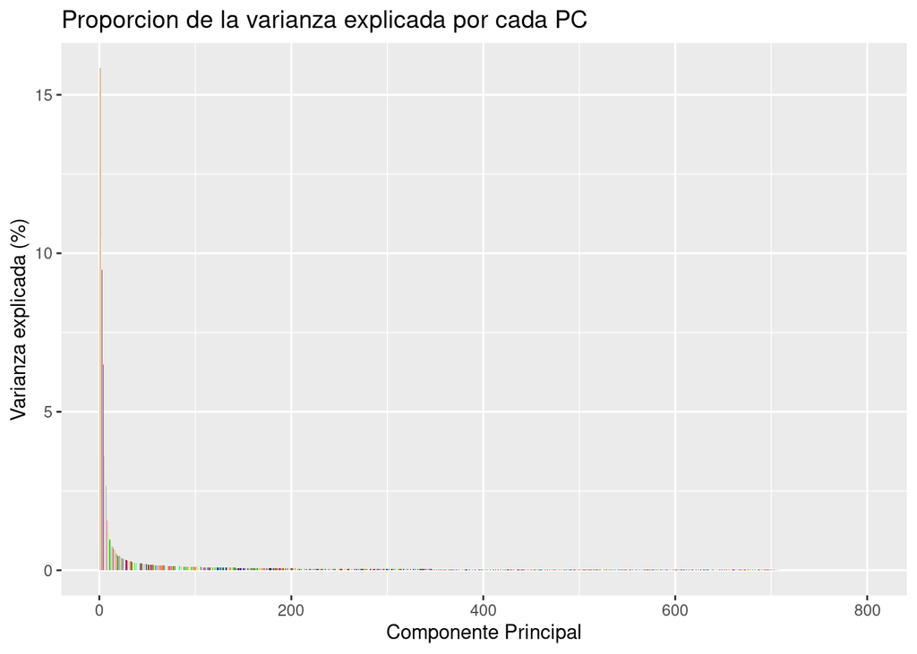

```r
# Obtener una paleta de colores
set.seed(15)
color <- grDevices::colors()[grep('gr(a|e)y', grDevices::colors(), invert = T)]
color <- sample(color, length(PCA$sdev), replace=TRUE)

# Calcular la proporcion de la varianza explicada por componente principal
exp_var <- PCA$sdev^2
exp_var <- (exp_var / sum(exp_var)) * 100
PC <- 1:length(PCA$sdev)
exp_var <- data.frame(exp_var, PC)

# Graficar la proporcion de la varianza explicada por componente principal
ggplot(exp_var, aes(x = PC, y = exp_var)) +
  geom_bar(stat = "identity", fill = color) +
  labs(title = "Proporcion de la varianza explicada por cada PC", x = "Componente Principal", y = "Varianza explicada (%)")
```

## 12. Obtén la proporción de la varianza cumulativa explicada por cada componente principal. ¿Cuántos componentes expresan el 65% de la varianza? ¿Cuántos el 85%? ¿Cuántos el 90%? Realiza una gráfica donde coloques 3 líneas horizontales de diferente color, una para cada porcentaje.

```r
# Calcular la suma cumulativa de la varianza
exp_var$var_cum <- cumsum(exp_var$exp_var)

# Calcular el numero de componentes que expresan tres umbrales de la varianza
for(lim in c(65, 85, 90)){
  print(exp_var[exp_var$var_cum >= lim, 2][1])
}
```

```
## [1] 27
## [1] 203
## [1] 311
```

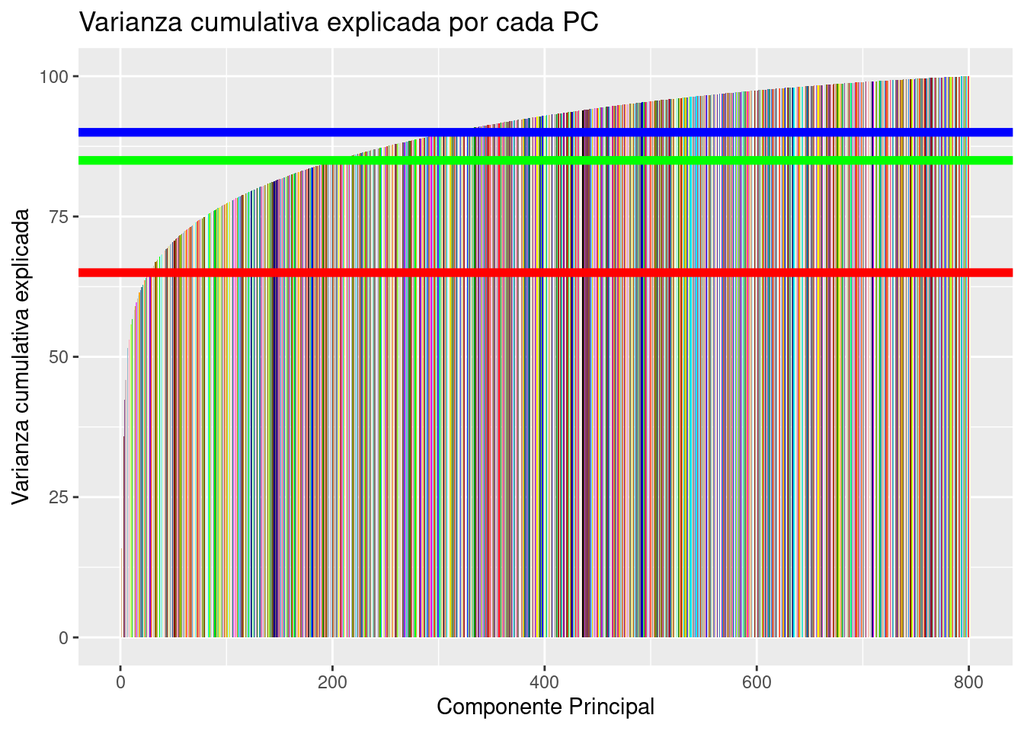

```r
# Graficar la varianza cumulativa explicada por cada componente principal
#y los umbrales de la varianza solicitados
ggplot(exp_var, aes(x = PC, y = var_cum)) + # graficamos
    geom_bar(stat = "identity", fill = color) +
    labs(title = "Varianza cumulativa explicada por cada PC", x = "Componente Principal", y = "Varianza cumulativa explicada") +
    geom_hline(yintercept = 65, colour="Red", size=2) + # colocamos una linea en la proporcion esperada
    geom_hline(yintercept = 85, colour="Green", size=2) +
    geom_hline(yintercept = 90, colour="Blue", size=2)
```

**27 componentes expresan el 65% de la varianza; 203 el 85%; y 311 el 90%.**

## 13. Grafica la contribución de las variables al PCA. Da una interpretación biológica a las variables que consideres pertinentes.

```r
# Importa la libreria requerida para graficar la contribucion
library(factoextra)
```

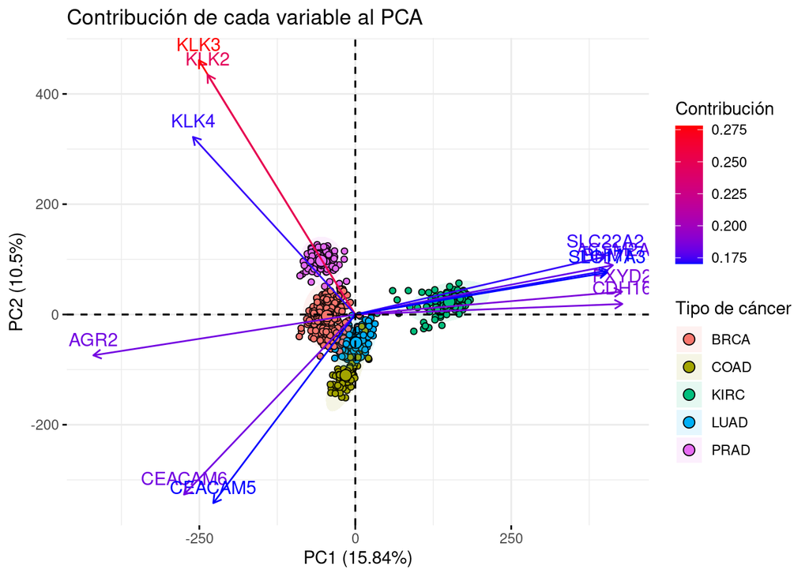

```r
# Graficar la contribucion de las variables al PCA
fviz_pca_biplot(PCA, geom.ind = "point",  fill.ind = data_cancer[,1], pointshape = 21,
                addEllipses = TRUE, select.var = list(contrib = 12), col.var = "contrib") +
  scale_color_gradient(low = "blue", high = "red") +
  labs(title = "Contribución de cada variable al PCA",
       x = paste("PC1 ", "(", round(exp_var$exp_var[1], 2), "%)", sep =""),
       y = paste("PC2 ", "(", round(exp_var$exp_var[2], 2), "%)", sep =""),
       color = "Contribución", fill = "Tipo de cáncer")
```

Por otro lado, los genes [CEACAM6](https://www.ncbi.nlm.nih.gov/gene/4680) y [CEACAM5](https://www.ncbi.nlm.nih.gov/gene/1048) se agrupan entre ellas, ya que ambas pertenecen a la familia del antígeno carcinoembrionario (CEA). Los miembros de esta familia desempeñan un papel en la adhesión celular y se utilizan ampliamente como biomarcadores para cánceres gastrointestinales. La asociación de estos genes con el tipo de cáncer no es muy clara, pero por la información que obtuve puedo asumir que se asocian con COAD, el cual es la abreviación de *Colon adenocarcinoma*.

Por su parte, el gen [AGR2](https://www.ncbi.nlm.nih.gov/gene/10551) se asocia con el tipo de cáncer BRCA, el cual es la abreviación de *Breast invasive carcinoma*. Haciendo una búsqueda rápida no encontré que estuviera directamente relacionado con este tipo específico de cáncer, pero si descubrí que juega un papel en la metástasis, la enfermedad inflamatoria intestinal y la progresión del cáncer. El hecho de que no se haya asociado con COAD me parece algo curioso, y su asociación con BRCA podría ser explicada por un mecanismo que involucre la metástasis.

Finalmente, los genes [FXYD2](https://www.ncbi.nlm.nih.gov/gene/486) y [CDH16](https://www.ncbi.nlm.nih.gov/gene/1014) se agruparon juntos, y se asociaron con el tipo de cánce KIRC, el cual es la abreviación de *Kidney renal clear cell carcinoma*. Esto corresponde con el hecho de que ambos genes se expresan en los riñones, aunque en mi búsqueda rápida no encontré una relación directa con el cáncer.

## 14. Realiza el PCA a mano para los mismos datos y compara tus resultados con el creado con prcomp().

**Mi computadora no tuvo la capacidad de correr el siguiente código. Por ello decidí solo poner el código, pero no correrlo.**

```r
# Centrar los datos para que la media de cada variable sea 0
#tge_centered <- apply(data_cancer[,2:ncol(data_cancer)], 2, function(x){ x - mean(x) })

# Calcular la matriz de covarianzas
#tge_covar <- cov(tge_centered)

# Calcular los eigenvalores y eigenvectores de la matriz de covarianzas
#tge_eigen <- eigen(tge_covar)

# Calcular el valor de cada componente principal
#tge_scores <- t(tge_eigen$vectors) %*% t(tge_centered)
#tge_pca <- t(tge_scores)
```